# Teaching

**Harvard T.H. Chan School of Public Health (Boston, MA)**  
*Instructor, Summer 2018*

[figure not shown]

**Methods and Computing in R**  
+ **Description:** A prepatory course for the incoming biostatistics doctoral students that covers computing in R and basic statistical topics + **Materials:** [Slides, exercises, and solutions](https://isabelfulcher.github.io/methodsprep/)

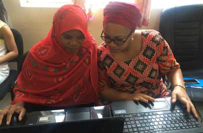

**Data Analysis and Stata Software Training Course**  
**D-tree International (Zanzibar, Tanzania)**  
*Course developer and instructor, Summer 2017*  
+ **Description:** An 8-week long statistical training course for D-tree International employees and their key partners at the Ministry of Health. The goal of the course was to equip trainees with tools to identify and answer pressing research questions that arose from the maternal and child health program in which they were all involved. + **Materials:** Contact for more information

[figure not shown]

**Stata Orientation for Incoming Graduate Students**  
**Harvard T.H. Chan School of Public Health (Boston, MA)**  
*Instructor, Summer 2016, 2017, 2018*  
+ **Description:** An introduction to Stata course for incoming graduate students + **Materials:**[Online Stata module](https://www.hsph.harvard.edu/orientation/stata-module/)

I have also served as a teaching assistant and research mentor for numerous other courses. Please see my [CV](https://isabelfulcher.github.io/img/ifulcher_cv.pdf) for a full list.